NetTreaty by NetSimR

# Reinsurance Pricing Report

Generated 20 November 2026, 13:55

## Key results

Layer

4,000,000 xs 1,000,000

1 reinstatement at 100%

Technical premium

3,008,724

Upfront; and 1,570,372 expected from reinstatements

Rate on line

75.22%

Payback 1.3 years

Expected layer loss

3,434,321

50% Burning cost, 50% exposure

Best value programme

Stop loss

Saves 1,818,857 a year

## Layer and settings

Layer

**Deductible**

1,000,000

**Limit**

4,000,000

**Reinstatements**

1

**Reinstatement rate**

100%

**Annual aggregate limit**

8,000,000

Rating year

**Rating year**

2025

**Subject premium**

60,000,000

**Loading**

25%

Experience

**Losses**

Example large losses

**Years**

2015 to 2024

**Claims inflation**

4% a year

**Reporting threshold**

500,000

**Weights**

By premium

**Pareto threshold**

750,000

**Pareto alpha**

Estimated

Exposure

**Profile**

Property: bands of sum insured

**Business**

Property

**Exposure curve**

Swiss Re Y3 (c = 3)

**Expected loss ratio**

55%

Blend

**Experience rate**

Burning cost

**Weight of the experience**

50%

Programmes

**Claim counts**

Poisson (200)

**Claim sizes**

LogNormal (11, 1.5)

**Simulated years**

20,000

**Level**

99.5%

**Cost of capital**

10%

## Pricing

The experience and exposure rates blended, and the technical premium of the layer.

Expected layer loss

3,434,321

Technical premium

3,008,724

Rate on line

75.22%

Payback

1.3 years

Rate

5.01%

Upfront premium over subject premium

### Methods

| Method | Rate | Expected loss | Upfront premium | Reinstatement premium | Rate on line |
| --- | --- | --- | --- | --- | --- |
| Burning cost | 4.97% | 2,983,162 | 2,641,275 | 1,336,275 | 66.03% |
| Pareto | 5.11% | 3,068,752 | 2,711,583 | 1,380,086 | 67.79% |
| Exposure | 6.48% | 3,885,481 | 3,368,518 | 1,812,123 | 84.21% |
| Blended | 5.72% | 3,434,321 | 3,008,724 | 1,570,372 | 75.22% |

Rates are shares of the subject premium of 60,000,000. The upfront and expected reinstatement premiums add up to the expected loss over one minus the loading of 25%. The reinstatement premium is the expected reinstated cover, at 100% of the upfront premium; the cover each method expects to use is that of the past years' layer losses at the rating year's premium, scaled to its expected loss. Blended: 50% Burning cost and 50% exposure. The aggregate terms apply to the burning cost only; the Pareto and exposure rates are before them.

### Expected loss by method

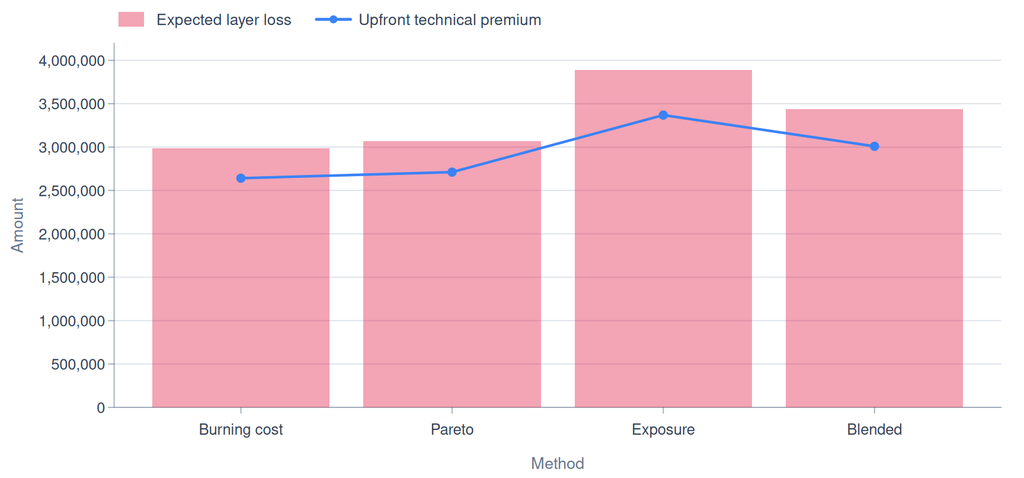

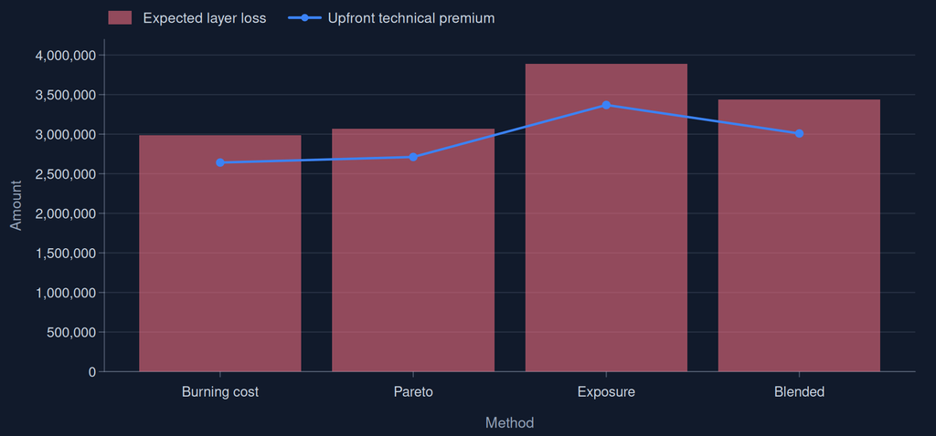

## Experience rating

The past large losses, brought to the rating year and put through the layer.

Years

10

2015 to 2024

Losses in the layer

25

Burning cost

4.97%

Of subject premium

Expected layer loss

2,983,162

Burning cost

Pareto

5.11%

Alpha 1.57

### Burning cost by year

| Year | Losses | In layer | Layer losses | Developed | On-level premium | Burning cost |
| --- | --- | --- | --- | --- | --- | --- |
| 2015 | 5 | 3 | 4,213,705 | 4,213,705 | 38,728,000 | 10.88% |
| 2016 | 3 | 2 | 550,148 | 550,148 | 40,800,000 | 1.35% |
| 2017 | 1 | 0 | 0 | 0 | 42,669,000 | 0.00% |
| 2018 | 4 | 2 | 441,448 | 445,863 | 45,696,000 | 0.98% |
| 2019 | 6 | 5 | 6,278,007 | 6,403,567 | 48,300,000 | 13.26% |
| 2020 | 2 | 1 | 44,983 | 46,783 | 50,774,000 | 0.09% |
| 2021 | 9 | 4 | 4,068,164 | 4,393,617 | 52,624,000 | 8.35% |
| 2022 | 6 | 4 | 4,893,267 | 5,627,257 | 54,796,000 | 10.27% |
| 2023 | 5 | 3 | 1,564,785 | 2,034,220 | 56,358,000 | 3.61% |
| 2024 | 3 | 1 | 366,560 | 604,824 | 58,400,000 | 1.04% |
| Total | 44 | 25 | 22,421,066 | 24,319,983 | 489,145,000 | 4.97% |

Developed: the layer losses times the year's development factor, after any annual aggregate terms. The burning cost is the total layer losses over the total on-level premium. Aggregate losses after the annual deductible of 0 and limit of 8,000,000.

### Burning cost by year

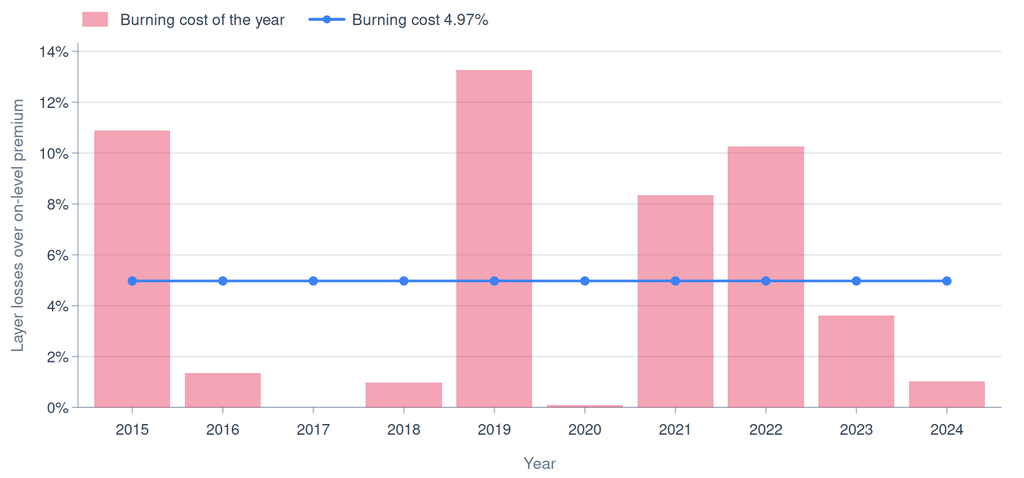

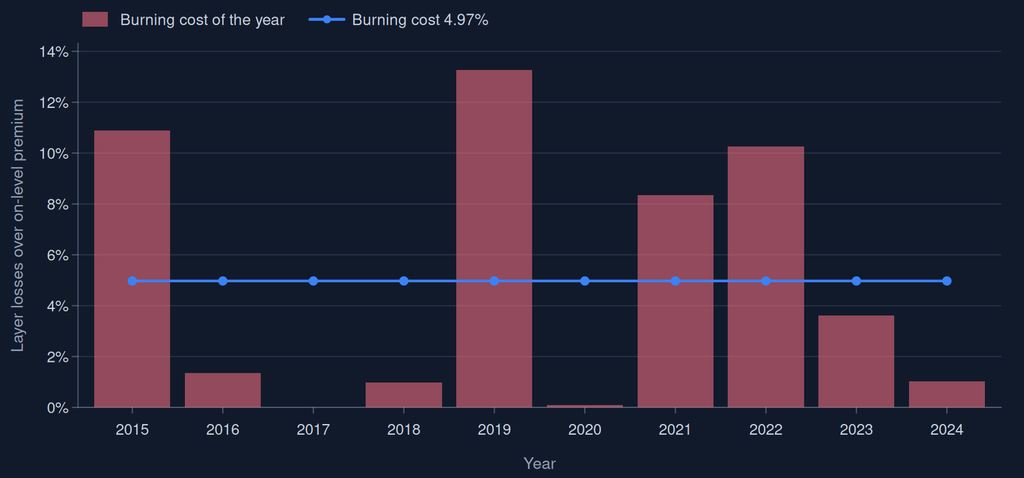

### Large losses against the layer

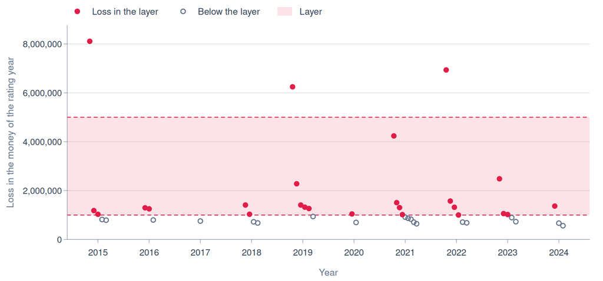

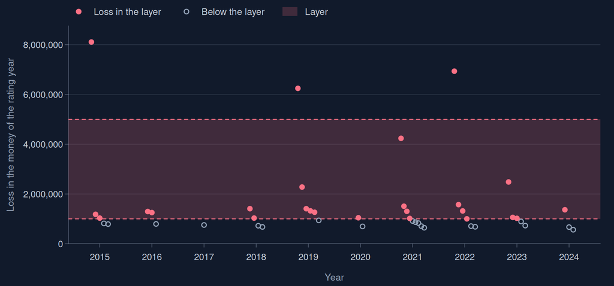

### Pareto fit

34 losses above 750,000 in the money of 2025; alpha 1.567. Expected 4.56 losses above the threshold in 2025, each with 672,701 in the layer on average.

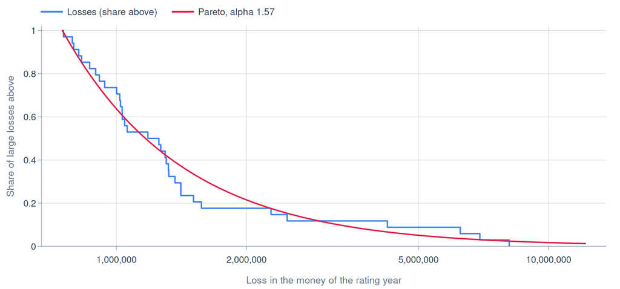

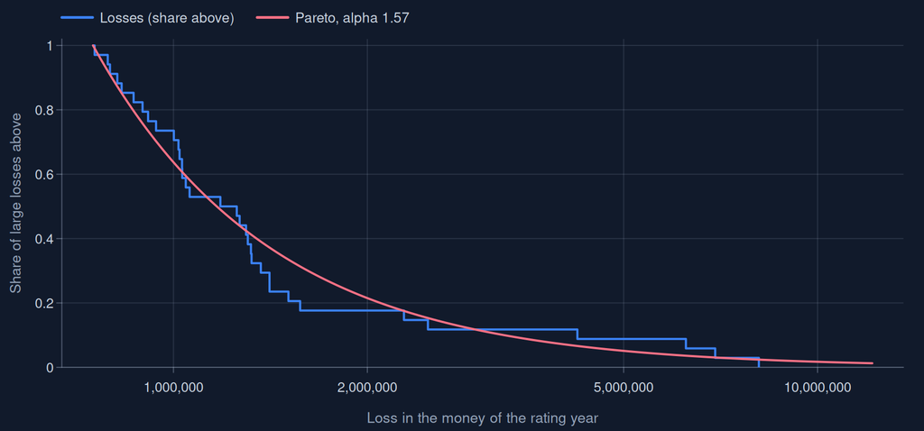

## Exposure rating

The layer's share of each band's expected loss, from the risk profile.

Bands

9

Property; Swiss Re Y3 (c = 3)

Ground-up loss

31,474,850

Of a premium of 57,227,000

Exposure rate

6.48%

Of subject premium

Expected layer loss

3,885,481

At the rating year's premium

### Bands of the risk profile

| Band | Sum insured | Premium | Expected loss | Layer, of sum insured | Layer share | Layer loss |
| --- | --- | --- | --- | --- | --- | --- |
| 0 to 250k | 138,000 | 11,012,000 | 6,056,600 | 100% to 100% | 0.00% | 0 |
| 250k to 500k | 382,000 | 12,014,000 | 6,607,700 | 100% to 100% | 0.00% | 0 |
| 500k to 1m | 750,000 | 10,695,000 | 5,882,250 | 100% to 100% | 0.00% | 0 |
| 1m to 2.5m | 1,715,000 | 9,124,000 | 5,018,200 | 58% to 100% | 17.88% | 897,355 |
| 2.5m to 5m | 3,638,000 | 5,439,000 | 2,991,450 | 27% to 100% | 37.74% | 1,129,057 |
| 5m to 10m | 7,200,000 | 3,629,000 | 1,995,950 | 14% to 69% | 40.35% | 805,416 |
| 10m to 25m | 16,450,000 | 2,895,000 | 1,592,250 | 6% to 30% | 33.18% | 528,245 |
| 25m to 50m | 34,875,000 | 1,674,000 | 920,700 | 3% to 14% | 27.68% | 254,804 |
| 50m to 100m | 69,000,000 | 745,000 | 409,750 | 1% to 7% | 22.22% | 91,030 |
| Total |  | 57,227,000 | 31,474,850 |  | 11.77% | 3,705,907 |

Expected loss: the premium times the loss ratio of 55.0%. Layer, of sum insured: the layer's deductible and top as shares of the band's sum insured; the layer share is the exposure curve's increase between them (Swiss Re Y3 (c = 3)). A simulated property portfolio: bands of sum insured with their risks, average sum insured and premium.

### Expected layer loss by band

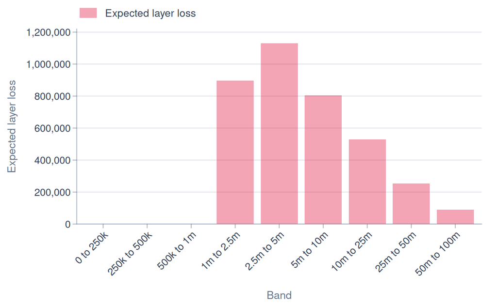

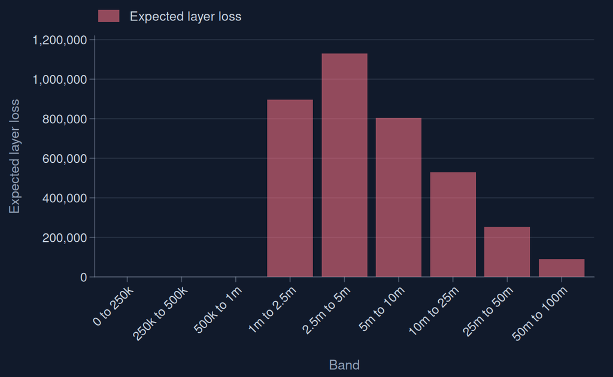

### Exposure curve

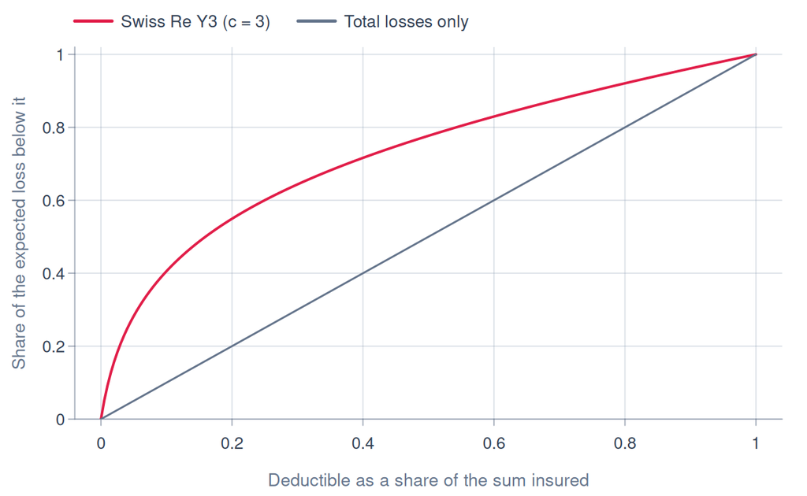

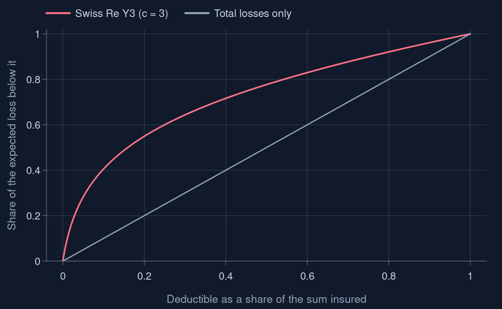

## Programmes

Reinsurance programmes compared by what they cost and the capital they save, on simulated years.

Capital without reinsurance

29,881,731

Best value

Stop loss

Saves 1,818,857 a year net of its margin

Its capital relief

20,957,734

For a margin of 276,917

Subject premium

60,000,000

20,000 simulated years

### Programmes

| Programme | Expected ceded | Reinsurance premium | Margin | Mean result | Loss-making years | Capital | Capital relief | Value |
| --- | --- | --- | --- | --- | --- | --- | --- | --- |
| No reinsurance | 0 | 0 | 0 | 23,093,246 | 1.3% | 29,881,731 | 0 | 0 |
| Quota share 30% | 11,072,026 | 13,500,000 | 2,427,974 | 20,665,272 | 0.5% | 20,917,212 | 8,964,519 | -1,531,522 |
| The layer | 5,163,258 | 6,884,343 | 1,721,086 | 21,372,161 | 1.2% | 27,875,073 | 2,006,658 | -1,520,420 |
| Stop loss | 830,750 | 1,107,667 | 276,917 | 22,816,330 | 0.1% | 8,923,997 | 20,957,734 | 1,818,857 |
| Quota share 20% and the layer | 11,104,944 | 13,964,791 | 2,859,847 | 20,233,399 | 0.6% | 21,258,307 | 8,623,424 | -1,997,505 |
| Surplus 4 lines | 6,901,926 | 7,855,199 | 953,273 | 22,139,974 | 0.9% | 26,745,607 | 3,136,124 | -639,660 |

Reinsurance premium: the premiums paid less any ceding commission, with the expected reinstatement premiums. Margin: that premium less the expected recoveries. Capital: the mean net result less its 0.5% worst. Value: 10% of the capital relief less the margin, positive when the capital saved is worth more than the reinsurance costs.

### Capital and margin

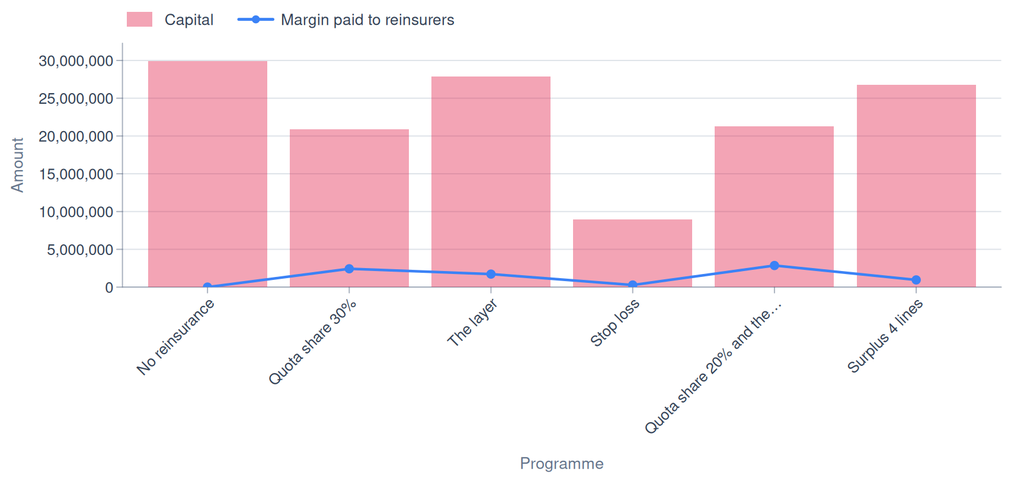

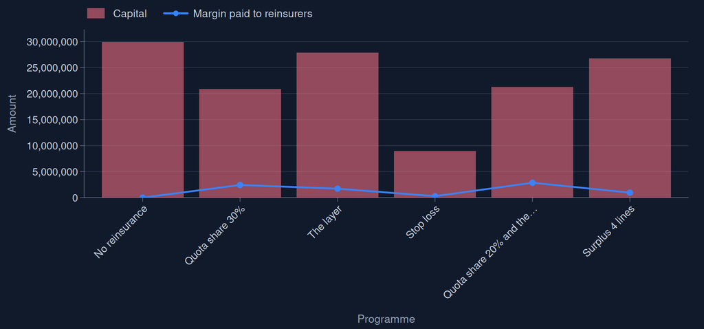

### Net result by return period

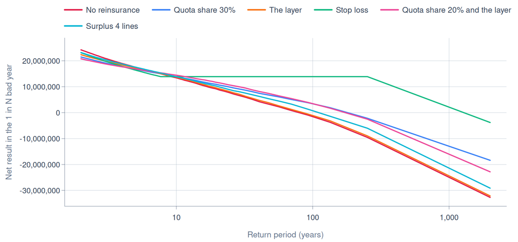

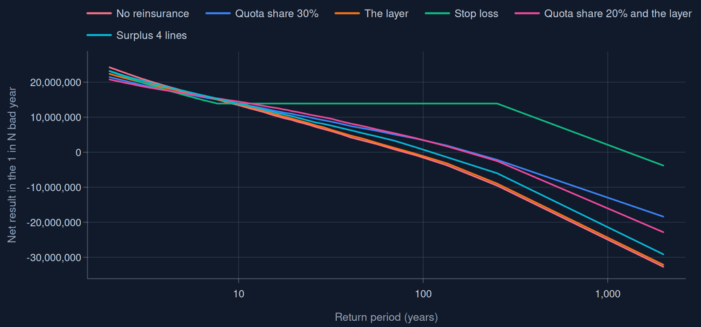

## How to read this report

- Rates are shares of the subject premium of the rating year; the expected layer loss is the rate times that premium.
- Burning cost: each year's losses are brought to the rating year by the claims inflation, put through the layer and developed, over the year's premium brought to the rating year's rate level.
- Pareto: the losses above the Pareto threshold, in the money of the rating year, give the expected number of losses and, from the Pareto's alpha, the share of each that falls in the layer.
- Exposure: each band of the risk profile gives its expected loss to the layer, from an exposure curve (property) or the limited expected values of a claim size distribution (casualty).
- The technical premium is the blended expected loss over one minus the loading, split between the upfront premium and the expected reinstatement premiums. The rate on line is the upfront premium over the limit, and the payback its inverse, in years.
- Programmes: the capital is the mean net result less its result in the bad year of the level chosen; the value of a programme is the cost of the capital it saves less the margin it pays the reinsurers.